# Assignment 2 FUNDAMENTALS OF MACHINE LEARNING

```r
var(Train_Norm_q5[,2:14])
```

```
##                             Age   Experience       Income       Family
## Age                 1.000000000  0.994236439 -0.048046189 -0.060928792
## Experience          0.994236439  1.000000000 -0.035604313 -0.066381963
## Income             -0.048046189 -0.035604313  1.000000000 -0.177306640
## Family             -0.060928792 -0.066381963 -0.177306640  1.000000000
## CCAvg              -0.037847973 -0.031713568  0.633847548 -0.113907098
## Mortgage           -0.023490974 -0.022277096  0.219004352 -0.042052594
## Securities.Account  0.007168541  0.006005190  0.007084735  0.002897944
## CD.Account          0.031485501  0.033075812  0.173915080  0.004289313
## Online              0.038579481  0.037382190  0.004651307  0.013576094
## CreditCard          0.007020028  0.006625588  0.000139475  0.016907405
## header              0.000000000  0.000000000  0.000000000  0.000000000
## Education_1        -0.017603009  0.006639420  0.235883965 -0.138584251
## Education_2        -0.013647017 -0.016231835 -0.122852072  0.153131335
##                           CCAvg    Mortgage Securities.Account   CD.Account
## Age                -0.037847973 -0.02349097        0.007168541  0.031485501
## Experience         -0.031713568 -0.02227710        0.006005190  0.033075812
## Income              0.633847548  0.21900435        0.007084735  0.173915080
## Family             -0.113907098 -0.04205259        0.002897944  0.004289313
## CCAvg               1.000000000  0.11017308        0.020055191  0.139504199
## Mortgage            0.110173084  1.00000000       -0.020695478  0.056628647
## Securities.Account  0.020055191 -0.02069548        1.000000000  0.321331082
## CD.Account          0.139504199  0.05662865        0.321331082  1.000000000
## Online             -0.022757780 -0.01539251        0.024518011  0.178429475
## CreditCard         -0.007074192 -0.03076387       -0.012782982  0.270786188
## header              0.000000000  0.00000000        0.000000000  0.000000000
## Education_1         0.169356644  0.05886753       -0.017741496 -0.017314632
## Education_2        -0.086516379 -0.03477219        0.004404275  0.011634694
##                          Online   CreditCard header  Education_1  Education_2
## Age                 0.038579481  0.007020028      0 -0.017603009 -0.013647017
## Experience          0.037382190  0.006625588      0  0.006639420 -0.016231835
## Income              0.004651307  0.000139475      0  0.235883965 -0.122852072
## Family              0.013576094  0.016907405      0 -0.138584251  0.153131335
## CCAvg              -0.022757780 -0.007074192      0  0.169356644 -0.086516379
## Mortgage           -0.015392506 -0.030763869      0  0.058867526 -0.034772190
## Securities.Account  0.024518011 -0.012782982      0 -0.017741496  0.004404275
## CD.Account          0.178429475  0.270786188      0 -0.017314632  0.011634694
## Online              1.000000000 -0.001755978      0  0.029208890  0.004213964
## CreditCard         -0.001755978  1.000000000      0 -0.005271392 -0.010390802
## header              0.000000000  0.000000000      0  0.000000000  0.000000000
## Education_1         0.029208890 -0.005271392      0  1.000000000 -0.538361740
## Education_2         0.004213964 -0.010390802      0 -0.538361740  1.000000000
```

```r
summary(Valid_Norm_q5)
```

```
##  Personal.Loan           Age              Experience             Income
##  Length:1500        Min.   :-1.955066   Min.   :-2.0156196   Min.   :-1.42911
##  Class :character   1st Qu.:-0.900212   1st Qu.:-0.8766931   1st Qu.:-0.76452
##  Mode  :character   Median :-0.021167   Median :-0.0005957   Median :-0.27144
##                     Mean   : 0.004852   Mean   : 0.0067635   Mean   :-0.05865
##                     3rd Qu.: 0.857877   3rd Qu.: 0.8755016   3rd Qu.: 0.39315
##                     Max.   : 1.912732   Max.   : 2.0144281   Max.   : 2.77282
##      Family             CCAvg            Mortgage        Securities.Account
##  Min.   :-1.21762   Min.   :-1.1365   Min.   :-0.56339   Min.   :-0.332526
##  1st Qu.:-1.21762   1st Qu.:-0.7876   1st Qu.:-0.56339   1st Qu.:-0.332526
##  Median :-0.35259   Median :-0.2642   Median :-0.56339   Median :-0.332526
##  Mean   :-0.01119   Mean   :-0.0467   Mean   :-0.04233   Mean   :-0.005342
##  3rd Qu.: 0.51245   3rd Qu.: 0.3173   3rd Qu.: 0.35571   3rd Qu.:-0.332526
##  Max.   : 1.37748   Max.   : 4.6787   Max.   : 5.40592   Max.   : 3.006085
##    CD.Account           Online           CreditCard       header
##  Min.   :-0.25881   Min.   :-1.22043   Min.   :-0.6589   Mode:logical
##  1st Qu.:-0.25881   1st Qu.:-1.22043   1st Qu.:-0.6589   TRUE:1500
##  Median :-0.25881   Median : 0.81906   Median :-0.6589
##  Mean   :-0.03627   Mean   :-0.01577   Mean   :-0.0264
##  3rd Qu.:-0.25881   3rd Qu.: 0.81906   3rd Qu.: 1.5171
##  Max.   : 3.86233   Max.   : 0.81906   Max.   : 1.5171
##   Education_1        Education_2        Education_3
##  Min.   :-0.86484   Min.   :-0.62225   Min.   :-0.64332
##  1st Qu.:-0.86484   1st Qu.:-0.62225   1st Qu.:-0.64332
##  Median :-0.86484   Median :-0.62225   Median :-0.64332
##  Mean   :-0.02964   Mean   : 0.00624   Mean   : 0.02607
##  3rd Qu.: 1.15582   3rd Qu.: 1.60643   3rd Qu.: 1.55381
##  Max.   : 1.15582   Max.   : 1.60643   Max.   : 1.55381
```

```r
var(Valid_Norm_q5[,2:14])
```

```
##                             Age   Experience       Income       Family
## Age                 1.001796577  0.992745503 -0.051375012 -0.030093057
## Experience          0.992745503  0.995114121 -0.047924629 -0.037954704
## Income             -0.051375012 -0.047924629  0.926431460 -0.128079895
## Family             -0.030093057 -0.037954704 -0.128079895  0.990564640
## CCAvg              -0.033429611 -0.036432461  0.616094760 -0.092519153
## Mortgage           -0.009787281 -0.007890278  0.181771064  0.011808472
## Securities.Account -0.002449638 -0.004165562  0.008880013  0.040428222
## CD.Account         -0.016669578 -0.013922774  0.174877002  0.009588890
## Online              0.006547364  0.006147788  0.037544142  0.003913689
## CreditCard          0.025258543  0.029679966  0.006521459 -0.003860870
## header              0.000000000  0.000000000  0.000000000  0.000000000
## Education_1        -0.032173958 -0.007922039  0.165860363 -0.071938622
## Education_2        -0.010352054 -0.011792363 -0.126744991  0.096530398
##                           CCAvg     Mortgage Securities.Account    CD.Account
## Age                -0.033429611 -0.009787281       -0.002449638 -0.0166695784
## Experience         -0.036432461 -0.007890278       -0.004165562 -0.0139227738
## Income              0.616094760  0.181771064        0.008880013  0.1748770016
## Family             -0.092519153  0.011808472        0.040428222  0.0095888901
## CCAvg               1.008403274  0.080155423        0.038686003  0.1095767684
## Mortgage            0.080155423  0.939721057        0.009133566  0.1023904888
## Securities.Account  0.038686003  0.009133566        0.985947209  0.2300366138
## CD.Account          0.109576768  0.102390489        0.230036614  0.8681781395
## Online              0.019383683  0.026284248       -0.040100232  0.1578726739
## CreditCard         -0.002820973  0.031499716       -0.032606678  0.2659514803
## header              0.000000000  0.000000000        0.000000000  0.0000000000
## Education_1         0.131354062  0.018936936        0.041584288 -0.0304431307
## Education_2        -0.102677907 -0.037887053       -0.007217329  0.0009681009
##                          Online   CreditCard header  Education_1   Education_2
## Age                 0.006547364  0.025258543      0 -0.032173958 -0.0103520539
## Experience          0.006147788  0.029679966      0 -0.007922039 -0.0117923634
## Income              0.037544142  0.006521459      0  0.165860363 -0.1267449909
## Family              0.003913689 -0.003860870      0 -0.071938622  0.0965303981
## CCAvg               0.019383683 -0.002820973      0  0.131354062 -0.1026779067
## Mortgage            0.026284248  0.031499716      0  0.018936936 -0.0378870526
## Securities.Account -0.040100232 -0.032606678      0  0.041584288 -0.0072173292
## CD.Account          0.157872674  0.265951480      0 -0.030443131  0.0009681009
## Online              1.006352569  0.007310634      0 -0.047323521  0.0671585621
## CreditCard          0.007310634  0.976895757      0  0.046306135 -0.0063151360
## header              0.000000000  0.000000000      0  0.000000000  0.0000000000
## Education_1        -0.047323521  0.046306135      0  0.990758756 -0.5252673635
## Education_2         0.067158562 -0.006315136      0 -0.525267363  1.0063735972
```

#modeling k-NN, Define predictors and labels for modeling on Train and Validation sets

```r
Train_Predictors_q5<- Train_Norm_q5[,2:14]
Train_Label_q5<- Train_Norm_q5[,1]
Train_Label_q5<-as.factor(Train_Label_q5)
Validation_Predictors_q5<- Valid_Norm_q5[,2:14]
Validation_Label_q5<- Valid_Norm_q5[,1]
Validation_Label_q5<-as.factor(Validation_Label_q5)
```

#hypertuning using the validation set. Compute knn for different k on Training and Validation

```r
Accuracy_q5<- data.frame(k = seq(1, 14, 1), accuracy = rep(0, 14))#create a table with two columns :k and accuracy
#To determin k, I am using the performance on the validation set value of k from 1 to 14
for(i in 1:14) {
     Pred.Model_k <- knn(Train_Predictors_q5, Validation_Predictors_q5,
                     cl = Train_Label_q5, k = i)
     Accuracy_q5[i, 2] <- confusionMatrix(Pred.Model_k, Validation_Label_q5)$overall[1]
}
Accuracy_q5
```

```
##     k  accuracy
## 1   1 0.9580000
## 2   2 0.9460000
## 3   3 0.9600000
## 4   4 0.9520000
## 5   5 0.9486667
## 6   6 0.9453333
## 7   7 0.9460000
## 8   8 0.9426667
## 9   9 0.9446667
## 10 10 0.9426667
## 11 11 0.9446667
## 12 12 0.9400000
## 13 13 0.9420000
## 14 14 0.9413333
```

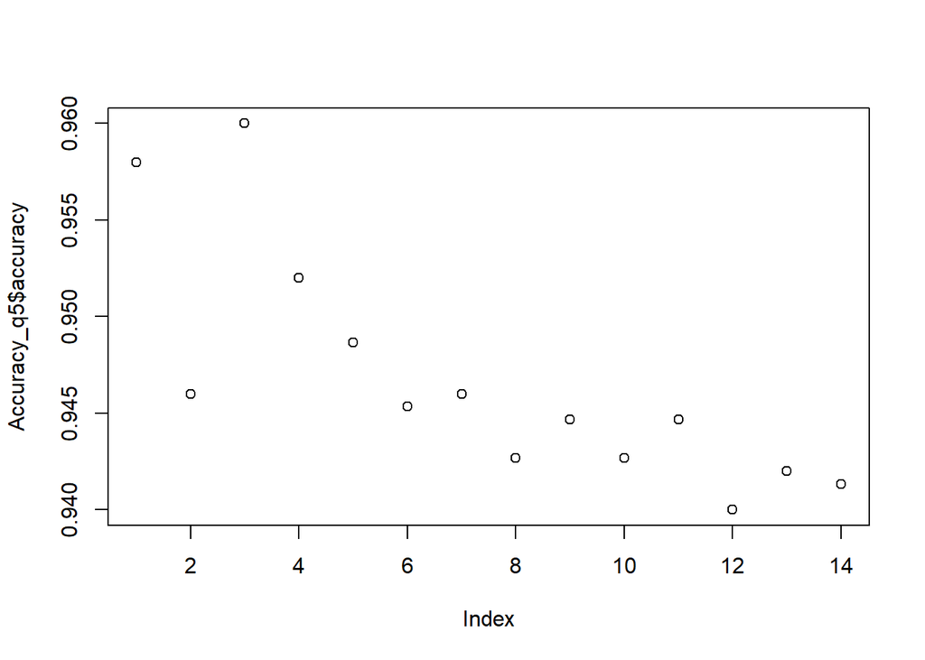

```r
plot(Accuracy_q5$accuracy)
```

#train a knn model for Training set.

```r
Pred.Model.train<-knn(Train_Predictors_q5, Train_Predictors_q5, cl=Train_Label_q5,k=3)
```

#confusion matrix for the Training set.

```r
CrossTable(x=Train_Label_q5,y= Pred.Model.train, prop.chisq = FALSE)
```

```
##
##
##    Cell Contents
## |-------------------------|
## |                       N |
## |           N / Row Total |
## |           N / Col Total |
## |         N / Table Total |
## |-------------------------|
##
##
## Total Observations in Table:  2500
##
##
##                | Pred.Model.train
## Train_Label_q5 |      Fail |   Success | Row Total |
## ---------------|-----------|-----------|-----------|
##           Fail |      2256 |         4 |      2260 |
##                |     0.998 |     0.002 |     0.904 |
##                |     0.973 |     0.022 |           |
##                |     0.902 |     0.002 |           |
## ---------------|-----------|-----------|-----------|
##        Success |        63 |       177 |       240 |
##                |     0.263 |     0.738 |     0.096 |
##                |     0.027 |     0.978 |           |
##                |     0.025 |     0.071 |           |
## ---------------|-----------|-----------|-----------|
##   Column Total |      2319 |       181 |      2500 |
##                |     0.928 |     0.072 |           |
## ---------------|-----------|-----------|-----------|
##
##
```

```r
confusionMatrix(Pred.Model.train, Train_Label_q5)
```

```
## Confusion Matrix and Statistics
##
##           Reference
## Prediction Fail Success
##    Fail    2256      63
##    Success    4     177
##
##                Accuracy : 0.9732
##                  95% CI : (0.9661, 0.9792)
##     No Information Rate : 0.904
##     P-Value [Acc > NIR] : < 2.2e-16
##
##                   Kappa : 0.8265
##
##  Mcnemar's Test P-Value : 1.382e-12
##
##             Sensitivity : 0.9982
##             Specificity : 0.7375
##          Pos Pred Value : 0.9728
##          Neg Pred Value : 0.9779
##              Prevalence : 0.9040
##          Detection Rate : 0.9024
##    Detection Prevalence : 0.9276
##       Balanced Accuracy : 0.8679
##
##        'Positive' Class : Fail
##
```

#train a knn model for the Validation set

```r
Pred.Model.validation<-knn(Train_Predictors_q5, Validation_Predictors_q5, cl=Train_Label_q5,k=3)
```

#confusion matrix for the validation set

```r
CrossTable(x=Validation_Label_q5,y= Pred.Model.validation, prop.chisq = FALSE)
```

```
##
##
##    Cell Contents
## |-------------------------|
## |                       N |
## |           N / Row Total |
## |           N / Col Total |
## |         N / Table Total |
## |-------------------------|
##
##
## Total Observations in Table:  1500
##
##
##                     | Pred.Model.validation
## Validation_Label_q5 |      Fail |   Success | Row Total |
## --------------------|-----------|-----------|-----------|
##                Fail |      1351 |         5 |      1356 |
##                     |     0.996 |     0.004 |     0.904 |
##                     |     0.961 |     0.053 |           |
##                     |     0.901 |     0.003 |           |
## --------------------|-----------|-----------|-----------|
##             Success |        55 |        89 |       144 |
##                     |     0.382 |     0.618 |     0.096 |
##                     |     0.039 |     0.947 |           |
##                     |     0.037 |     0.059 |           |
## --------------------|-----------|-----------|-----------|
##        Column Total |      1406 |        94 |      1500 |
##                     |     0.937 |     0.063 |           |
## --------------------|-----------|-----------|-----------|
##
##
```

```r
confusionMatrix(Pred.Model.validation,Validation_Label_q5)
```

```
## Confusion Matrix and Statistics
##
##           Reference
## Prediction Fail Success
##    Fail    1351      55
##    Success    5      89
##
##                Accuracy : 0.96
##                  95% CI : (0.9488, 0.9693)
##     No Information Rate : 0.904
##     P-Value [Acc > NIR] : < 2.2e-16
##
##                   Kappa : 0.7272
##
##  Mcnemar's Test P-Value : 2.518e-10
##
##             Sensitivity : 0.9963
##             Specificity : 0.6181
##          Pos Pred Value : 0.9609
##          Neg Pred Value : 0.9468
##              Prevalence : 0.9040
##          Detection Rate : 0.9007
##    Detection Prevalence : 0.9373
##       Balanced Accuracy : 0.8072
##
##        'Positive' Class : Fail
##
```

#data Normalization on (Train+Validation) set and apply it to Test set (z-score scaling using “center” and “scale” as input method parameters)

```r
# Use combined set to normalize
norm.values.combined.q5 <- preProcess(TraVal_Data_q5, method=c("center", "scale"))
Traval_Norm_q5<-predict(norm.values.combined.q5, TraVal_Data_q5)
Test_Norm_q5<-predict(norm.values.combined.q5, Test_Data_q5)

# Check the mean and variance of variables in the other sets
summary(Traval_Norm_q5)
```

```
##  Personal.Loan           Age             Experience            Income
##  Length:4000        Min.   :-1.95647   Min.   :-2.020249   Min.   :-1.4265
##  Class :character   1st Qu.:-0.90184   1st Qu.:-0.880141   1st Qu.:-0.7528
##  Mode  :character   Median :-0.02298   Median :-0.003135   Median :-0.2094
##                     Mean   : 0.00000   Mean   : 0.000000   Mean   : 0.0000
##                     3rd Qu.: 0.85587   3rd Qu.: 0.873870   3rd Qu.: 0.5295
##                     Max.   : 1.91050   Max.   : 2.013978   Max.   : 3.2680
##      Family            CCAvg            Mortgage       Securities.Account
##  Min.   :-1.2157   Min.   :-1.1171   Min.   :-0.5538   Min.   :-0.3314
##  1st Qu.:-1.2157   1st Qu.:-0.7107   1st Qu.:-0.5538   1st Qu.:-0.3314
##  Median :-0.3490   Median :-0.2463   Median :-0.5538   Median :-0.3314
##  Mean   : 0.0000   Mean   : 0.0000   Mean   : 0.0000   Mean   : 0.0000
##  3rd Qu.: 0.5176   3rd Qu.: 0.3342   3rd Qu.: 0.4247   3rd Qu.:-0.3314
##  Max.   : 1.3843   Max.   : 4.6882   Max.   : 5.6598   Max.   : 3.0164
##    CD.Account          Online          CreditCard       header
##  Min.   :-0.2515   Min.   :-1.2132   Min.   :-0.6518   Mode:logical
##  1st Qu.:-0.2515   1st Qu.:-1.2132   1st Qu.:-0.6518   TRUE:4000
##  Median :-0.2515   Median : 0.8241   Median :-0.6518
##  Mean   : 0.0000   Mean   : 0.0000   Mean   : 0.0000
##  3rd Qu.:-0.2515   3rd Qu.: 0.8241   3rd Qu.: 1.5337
##  Max.   : 3.9753   Max.   : 0.8241   Max.   : 1.5337
##   Education_1       Education_2       Education_3
##  Min.   :-0.8552   Min.   :-0.6239   Min.   :-0.6503
##  1st Qu.:-0.8552   1st Qu.:-0.6239   1st Qu.:-0.6503
##  Median :-0.8552   Median :-0.6239   Median :-0.6503
##  Mean   : 0.0000   Mean   : 0.0000   Mean   : 0.0000
##  3rd Qu.: 1.1690   3rd Qu.: 1.6024   3rd Qu.: 1.5374
##  Max.   : 1.1690   Max.   : 1.6024   Max.   : 1.5374
```

```r
var(Traval_Norm_q5[,2:14])
```

```
##                             Age   Experience       Income       Family
## Age                 1.000000000  0.994253646 -0.050018488 -0.049450110
## Experience          0.994253646  1.000000000 -0.040904814 -0.055890215
## Income             -0.050018488 -0.040904814  1.000000000 -0.161147080
## Family             -0.049450110 -0.055890215 -0.161147080  1.000000000
## CCAvg              -0.036166041 -0.033526194  0.635249961 -0.105757974
## Mortgage           -0.018602331 -0.017156876  0.210786796 -0.022030953
## Securities.Account  0.003564431  0.002191085  0.007959293  0.017058277
## CD.Account          0.013725876  0.015803804  0.181680490  0.006545439
## Online              0.026510158  0.025638352  0.017414776  0.010000058
## CreditCard          0.013882718  0.015306736  0.002947557  0.009245401
## header              0.000000000  0.000000000  0.000000000  0.000000000
## Education_1        -0.023129805  0.001135665  0.213254711 -0.113903968
## Education_2        -0.012385455 -0.014553243 -0.125946231  0.131966935
##                           CCAvg      Mortgage Securities.Account   CD.Account
## Age                -0.036166041 -0.0186023306       3.564431e-03  0.013725876
## Experience         -0.033526194 -0.0171568758       2.191085e-03  0.015803804
## Income              0.635249961  0.2107867962       7.959293e-03  0.181680490
## Family             -0.105757974 -0.0220309531       1.705828e-02  0.006545439
## CCAvg               1.000000000  0.1003192850       2.712105e-02  0.131721046
## Mortgage            0.100319285  1.0000000000      -9.590367e-03  0.076894905
## Securities.Account  0.027121050 -0.0095903666       1.000000e+00  0.295247357
## CD.Account          0.131721046  0.0768949046       2.952474e-01  1.000000000
## Online             -0.006763999  0.0003941556       3.104068e-04  0.174999813
## CreditCard         -0.005203034 -0.0072685037      -2.032242e-02  0.277243675
## header              0.000000000  0.0000000000       0.000000e+00  0.000000000
## Education_1         0.155402217  0.0447616297       4.558510e-03 -0.022582448
## Education_2        -0.092364390 -0.0363644652       3.913954e-05  0.007766372
##                           Online   CreditCard header   Education_1
## Age                 0.0265101582  0.013882718      0 -0.0231298050
## Experience          0.0256383516  0.015306736      0  0.0011356654
## Income              0.0174147758  0.002947557      0  0.2132547112
## Family              0.0100000583  0.009245401      0 -0.1139039676
## CCAvg              -0.0067639991 -0.005203034      0  0.1554022171
## Mortgage            0.0003941556 -0.007268504      0  0.0447616297
## Securities.Account  0.0003104068 -0.020322417      0  0.0045585103
## CD.Account          0.1749998126  0.277243675      0 -0.0225824477
## Online              1.0000000000  0.001746397      0  0.0006238869
## CreditCard          0.0017463969  1.000000000      0  0.0143347604
## header              0.0000000000  0.000000000      0  0.0000000000
## Education_1         0.0006238869  0.014334760      0  1.0000000000
## Education_2         0.0277240947 -0.008928683      0 -0.5337272002
##                      Education_2
## Age                -1.238546e-02
## Experience         -1.455324e-02
## Income             -1.259462e-01
## Family              1.319669e-01
## CCAvg              -9.236439e-02
## Mortgage           -3.636447e-02
## Securities.Account  3.913954e-05
## CD.Account          7.766372e-03
## Online              2.772409e-02
## CreditCard         -8.928683e-03
## header              0.000000e+00
## Education_1        -5.337272e-01
## Education_2         1.000000e+00
```

```r
summary(Test_Norm_q5)
```

```
##  Personal.Loan           Age             Experience           Income
##  Length:1000        Min.   :-1.95647   Min.   :-2.02025   Min.   :-1.4265
##  Class :character   1st Qu.:-0.90184   1st Qu.:-0.88014   1st Qu.:-0.7528
##  Mode  :character   Median : 0.06490   Median : 0.08457   Median :-0.2094
##                     Mean   : 0.03379   Mean   : 0.03019   Mean   : 0.0151
##                     3rd Qu.: 0.94376   3rd Qu.: 0.87387   3rd Qu.: 0.6165
##                     Max.   : 1.91050   Max.   : 1.83858   Max.   : 2.8551
##      Family             CCAvg             Mortgage         Securities.Account
##  Min.   :-1.21571   Min.   :-1.11711   Min.   :-0.553765   Min.   :-0.33144
##  1st Qu.:-1.21571   1st Qu.:-0.71074   1st Qu.:-0.553765   1st Qu.:-0.33144
##  Median :-0.34905   Median :-0.18826   Median :-0.553765   Median :-0.33144
##  Mean   :-0.02752   Mean   : 0.03964   Mean   :-0.004597   Mean   : 0.09039
##  3rd Qu.: 0.51761   3rd Qu.: 0.39227   3rd Qu.: 0.463884   3rd Qu.:-0.33144
##  Max.   : 1.38428   Max.   : 4.68821   Max.   : 5.141154   Max.   : 3.01641
##    CD.Account           Online           CreditCard        header
##  Min.   :-0.25149   Min.   :-1.21319   Min.   :-0.65185   Mode:logical
##  1st Qu.:-0.25149   1st Qu.:-1.21319   1st Qu.:-0.65185   TRUE:1000
##  Median :-0.25149   Median : 0.82407   Median :-0.65185
##  Mean   : 0.01902   Mean   : 0.01324   Mean   :-0.04644
##  3rd Qu.:-0.25149   3rd Qu.: 0.82407   3rd Qu.: 1.53372
##  Max.   : 3.97527   Max.   : 0.82407   Max.   : 1.53372
##   Education_1       Education_2         Education_3
##  Min.   :-0.8552   Min.   :-0.623918   Min.   :-0.65029
##  1st Qu.:-0.8552   1st Qu.:-0.623918   1st Qu.:-0.65029
##  Median :-0.8552   Median :-0.623918   Median :-0.65029
##  Mean   :-0.0334   Mean   : 0.003896   Mean   : 0.03227
##  3rd Qu.: 1.1690   3rd Qu.: 1.602373   3rd Qu.: 1.53739
##  Max.   : 1.1690   Max.   : 1.602373   Max.   : 1.53739
```

```r
var(Test_Norm_q5[,2:14])
```

```
##                            Age  Experience       Income      Family
## Age                 1.07490136  1.06009145 -0.078947787 -0.03405533
## Experience          1.06009145  1.05794444 -0.071136616 -0.03872465
## Income             -0.07894779 -0.07113662  1.005818383 -0.13889354
## Family             -0.03405533 -0.03872465 -0.138893537  0.94685521
## CCAvg              -0.12232810 -0.12244810  0.737857704 -0.12757900
## Mortgage            0.01167761  0.01578723  0.186762447 -0.01318856
## Securities.Account -0.01896606 -0.01730496 -0.046365390  0.03558999
## CD.Account         -0.01462981 -0.01125056  0.128268462  0.04494080
## Online             -0.03743862 -0.03304384  0.001211767  0.01176721
## CreditCard         -0.01575518 -0.01520741 -0.023128208  0.01940222
## header              0.00000000  0.00000000  0.000000000  0.00000000
## Education_1        -0.04634928 -0.01835311  0.237059609 -0.13456025
## Education_2        -0.03254561 -0.03345194 -0.138768533  0.16489683
##                           CCAvg     Mortgage Securities.Account    CD.Account
## Age                -0.122328100  0.011677615       -0.018966058 -0.0146298143
## Experience         -0.122448098  0.015787229       -0.017304956 -0.0112505566
## Income              0.737857704  0.186762447       -0.046365390  0.1282684618
## Family             -0.127578997 -0.013188555        0.035589989  0.0449408045
## CCAvg               1.146634243  0.153910062       -0.033019723  0.1701578502
## Mortgage            0.153910062  0.953837990        0.011132869  0.1401878026
## Securities.Account -0.033019723  0.011132869        1.235514699  0.4523645551
## CD.Account          0.170157850  0.140187803        0.452364555  1.0712873623
## Online              0.008333155 -0.031369662        0.062455680  0.1850803851
## CreditCard         -0.011518337 -0.006937508        0.008042051  0.2891760108
## header              0.000000000  0.000000000        0.000000000  0.0000000000
## Education_1         0.175080688  0.033825965        0.019292396  0.0172658999
## Education_2        -0.089334287 -0.012880650        0.025873869 -0.0004521324
##                          Online   CreditCard header Education_1   Education_2
## Age                -0.037438621 -0.015755178      0 -0.04634928 -0.0325456077
## Experience         -0.033043839 -0.015207412      0 -0.01835311 -0.0334519411
## Income              0.001211767 -0.023128208      0  0.23705961 -0.1387685327
## Family              0.011767213  0.019402224      0 -0.13456025  0.1648968286
## CCAvg               0.008333155 -0.011518337      0  0.17508069 -0.0893342874
## Mortgage           -0.031369662 -0.006937508      0  0.03382597 -0.0128806497
## Securities.Account  0.062455680  0.008042051      0  0.01929240  0.0258738689
## CD.Account          0.185080385  0.289176011      0  0.01726590 -0.0004521324
## Online              0.995417327  0.014467479      0  0.01481115 -0.0080086758
## CreditCard          0.014467479  0.957593341      0  0.01566798 -0.0249081553
## header              0.000000000  0.000000000      0  0.00000000  0.0000000000
## Education_1         0.014811153  0.015667978      0  0.98914441 -0.5164735299
## Education_2        -0.008008676 -0.024908155      0 -0.51647353  1.0045514441
```

#modeling k-NN, Define predictors and labels for modeling on Train+Validation and test sets

```r
TraVal_Predictors_q5<- TraVal_Norm_q5[,2:14]
TraVal_Label_q5 <- TraVal_Norm_q5[,1]
TraVal_Label_q5<-as.factor(TraVal_Label_q5)
Test_Predictors_q5<-Test_Norm_q5[,2:14]
Test_Label_q5<- Test_Norm_q5[,1]
Test_Label_q5<-as.factor(Test_Label_q5)
```

#train a knn model

```r
Pred.Model.test<-knn(TraVal_Predictors_q5, Test_Predictors_q5, cl=TraVal_Label_q5,k=3)
```

#confusion matrix for the test data

```r
CrossTable(x=Test_Label_q5,y= Pred.Model.test, prop.chisq = FALSE)
```

```
##
##
##    Cell Contents
## |-------------------------|
## |                       N |
## |         N / Table Total |
## |-------------------------|
##
##
## Total Observations in Table:  1000
##
##
##               | Pred.Model.test
## Test_Label_q5 |      Fail | Row Total |
## --------------|-----------|-----------|
##          Fail |       904 |       904 |
##               |     0.904 |           |
## --------------|-----------|-----------|
##       Success |        96 |        96 |
##               |     0.096 |           |
## --------------|-----------|-----------|
##  Column Total |      1000 |      1000 |
## --------------|-----------|-----------|
##
##
```

```r
confusionMatrix(Pred.Model.test,Test_Label_q5)
```

```
## Confusion Matrix and Statistics
##
##           Reference
## Prediction Fail Success
##    Fail     904      96
##    Success    0       0
##
##                Accuracy : 0.904
##                  95% CI : (0.884, 0.9215)
##     No Information Rate : 0.904
##     P-Value [Acc > NIR] : 0.5271
##
##                   Kappa : 0
##
##  Mcnemar's Test P-Value : <2e-16
##
##             Sensitivity : 1.000
##             Specificity : 0.000
##          Pos Pred Value : 0.904
##          Neg Pred Value :   NaN
##              Prevalence : 0.904
##          Detection Rate : 0.904
##    Detection Prevalence : 1.000
##       Balanced Accuracy : 0.500
##
##        'Positive' Class : Fail
##
```